# Reproducible Research: Peer Assessment 1

## Inroduction

This is an R Markdown document produced for Peer Assessment 1 in the 5th course (Reproducible Research) of the Data Science Specialization on Coursera. The underlying data is from a personal activity monitoring device. This device collects data at 5 minute intervals through out the day. The data consists of two months of data from an anonymous individual collected during the months of October and November, 2012 and include the number of steps taken in 5 minute intervals each day.

## Loading and preprocessing the data

If the original data with the source file is not available yet, it is downloaded and unziped in the subdirectory `data`.

```r
if(!file.exists("data")) {
        dir.create("data")
}
if(!file.exists('./activity.zip')) {
        fileUrl <- "https://d396qusza40orc.cloudfront.net/repdata%2Fdata%2Factivity.zip"
        download.file(fileUrl,
                      destfile="./activity.zip",
                      method="curl")
        dateDownloaded <- date()
}
if(!file.exists('./data/activity.csv')) {
        unzip("./activity.zip", exdir="./data/")
}
data <- read.csv("./data/activity.csv")
```

Now the data is available in a data frame with variables:

- `data$steps`
- `data$date`
- `data$interval`

## What is mean total number of steps taken per day?

To calculate some statistical properties about steps taken per day the data is aggregated per day. Additionally, median and mean is computed.

```r
daily_steps <- aggregate(data[,'steps'], by = list(data$date), FUN = sum)
median_steps_per_day <- median(daily_steps$x, na.rm=TRUE)
mean_steps_per_day = mean(daily_steps$x, na.rm=TRUE)
mean_steps_per_day_string <- prettyNum(mean_steps_per_day, digits = 0,
                                       big.mark = ",", scientific = FALSE)
```

This histogram shows the distribution of daily steps.

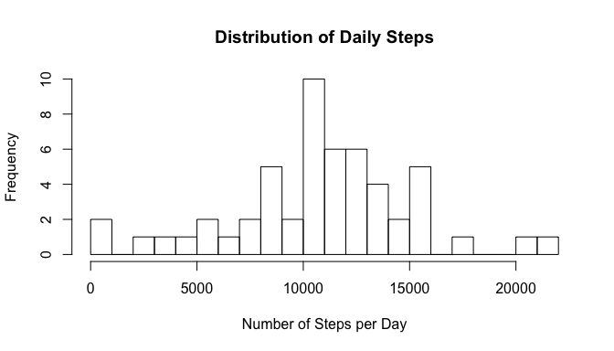

```r
hist(daily_steps$x, breaks=20,
     main="Distribution of Daily Steps",
     xlab="Number of Steps per Day")
```

The mean steps per day are 10,766 (exact: 1.076618910^{4}) and the median steps per day are 10765.

## What is the average daily activity pattern?

The average daily activity pattern uses the average steps per 5-min interval.

```r
interval_steps <- aggregate(data[,'steps'],
                            by = list(data$interval),
                            FUN = mean,
                            na.rm = TRUE)
max_steps <- max(interval_steps$x)
max_steps_time <- interval_steps$Group.1[which.max(interval_steps$x)]
max_steps_string <- paste(max_steps_time %/% 100, max_steps_time %% 100,
                          sep=':')
```

This line plot shows the activity pattern of average steps over the course of a day.

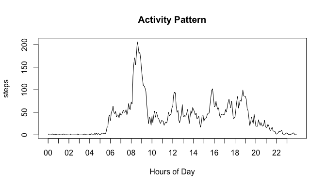

```r
start_time <- as.POSIXct(strptime("1970-01-01 00:00:00", "%Y-%m-%d %H:%M:%S"))
end_time <- as.POSIXct(strptime("1970-01-01 23:55:01", "%Y-%m-%d %H:%M:%S"))
with(interval_steps, {
        time <- strptime(paste(1970, 1, Group.1 %/% 100, Group.1 %% 100),
                         "%Y %j %H %M")
        plot(time, x, type = 'l', xaxt = 'n',
             xlab='Hours of Day', ylab='steps', main='Activity Pattern')
        axis.POSIXct(1, at = seq(start_time, end_time, by="hours"),
                     format = "%H")
})
```

The most average steps (206) on a day are at 8:35.

## Imputing missing values

Only 15264 out of 17568 records are complete. As (very simple) strategy for filling the missing values we use the general average of steps in an interval.

```r
data_complete <- data
data_complete[!complete.cases(data_complete$steps),'steps'] =
        mean(data[complete.cases(data$steps),'steps'])
```

Now, we calculate again some statistical properties about steps taken per day from the data with imputed values. Additionally, median and mean is computed.

```r
daily_steps_c <- aggregate(data_complete[,'steps'],
                           by = list(data_complete$date),
                           FUN = sum)
median_steps_per_day_c <- median(daily_steps_c$x)
median_steps_per_day_string_c <- prettyNum(median_steps_per_day_c, digits = 0,
                                           big.mark = ",", scientific = FALSE)
mean_steps_per_day_c <- mean(daily_steps_c$x)
mean_steps_per_day_string_c <- prettyNum(mean_steps_per_day_c, digits = 0,
                                         big.mark = ",", scientific = FALSE)
```

This histogram shows the distribution of daily steps with imputed data.

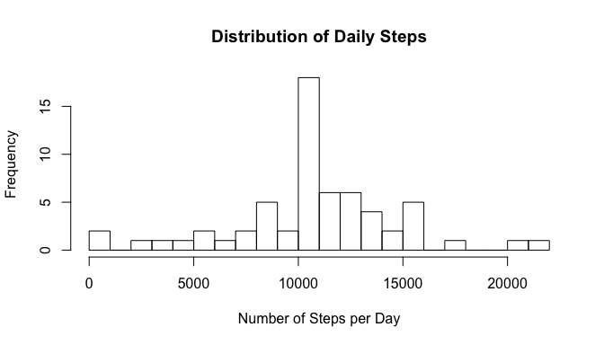

```r
hist(daily_steps_c$x, breaks=20,
     main="Distribution of Daily Steps",
     xlab="Number of Steps per Day")
```

The mean steps per day are 10,766 (exact: 1.076618910^{4}) and the median steps per day are 10,766 (exact: 1.076618910^{4}).

### Explanation

Why is the distribution only affected in the 10,000 block? If we take a look what values we are missing, we find the following result.

```r
tmp <- data[!complete.cases(data),'date']
head(sort(table(tmp), decreasing = TRUE),10)
```

```
## tmp
## 2012-10-01 2012-10-08 2012-11-01 2012-11-04 2012-11-09 2012-11-10
##        288        288        288        288        288        288
## 2012-11-14 2012-11-30 2012-10-02 2012-10-03
##        288        288          0          0
```

## Are there differences in activity patterns between weekdays and weekends?

To compare differences in activity patterns between weekdays and weekends, a factor varialbe `data$day_type` is created.

```r
tmp_day <- (weekdays(as.POSIXct(data$date)) == "Sunday" |
            weekdays(as.POSIXct(data$date)) == "Saturday")
data$day_type<-factor(tmp_day, labels=c("weekday", "weekend"))
```

The following line plots compare activity patterns between weekdays and weekends.

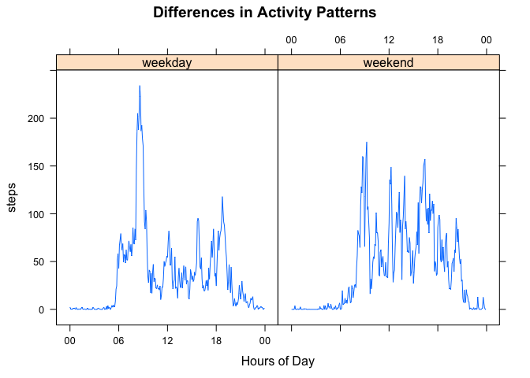

```r
library(lattice)
data_weekday <- aggregate(data[data$day_type=="weekday", 'steps'],
                          by = list(data[data$day_type=="weekday",]$interval),
                          FUN = mean,
                          na.rm = TRUE)
data_weekday$daytime <- strptime(paste(1970, 1, data_weekday$Group.1 %/% 100,
                          data_weekday$Group.1 %% 100), "%Y %j %H %M")
data_weekday$day_type <- factor("weekday")
data_weekend <- aggregate(data[data$day_type=="weekend", 'steps'],
                          by = list(data[data$day_type=="weekend",]$interval),
                          FUN = mean,
                          na.rm = TRUE)
data_weekend$daytime <- strptime(paste(1970, 1, data_weekend$Group.1 %/% 100,
                          data_weekend$Group.1 %% 100), "%Y %j %H %M")
data_weekend$day_type <- factor("weekend")
data_all <- rbind(data_weekday, data_weekend)
xyplot(x ~ as.POSIXct(daytime) | day_type,
       data=data_all, type='l',
       scales=list(x=list(format = "%H")),
       xlab='Hours of Day', ylab="steps",
       main='Differences in Activity Patterns')
```